# Afrobarometer - Côte d’Ivoire 2023

civ_afrobarometer_2023

Auteur·rice

Claude Grasland & Jean-Paul Nguesso

Date de publication

2025-03-28

**Télécharger le jeu de données**

- [Cliquer ici](https://github.com/worldregio/afromapr/raw/refs/heads/main/datazip/civ_afrobarometer_2023.zip)

### Source

Les enquêtes [Afrobarometer](https://www.afrobarometer.org/)) sont réalisées par vagues à laquelle tous les pays du continent sont invités à participer. Au cours de chacune des vagues, des questions identiques sont posés aux citoyens de chacun des pays qui participent à l’enquête ce qui permet de comparer leurs opinions. Toutefois certains pays refusent de participer ou bien participent mais ne posent pas toutes les questions et en ajoutent parfois d’autres. Malgré ces limites il s’agit d’une source majeure d’information sur l’évolution des opinions publiques en Afrique puisque la première vague remonte à 1999 et que nous en sommes aujoud’hui à la dixième.

La Côte d’Ivoire a participé aux enquêtes Afrobarometer de 2013, 2014, 2019, 2021 and 2023. Celles-ci ont été réalisées par le laboratoire [Zechlab](https://www.zechlab.com/). Les fichiers de résultats sont librement accessibles sur le site [Afrobarometer](https://www.afrobarometer.org/)) qui fournit à la fois les données (au format SPSS) et les métadonnées relatives aux questions posées et aux modes de collecte.

### Conversation de SPSS vers R

Bien qu’elles soient fournies au format SPSS (extension *.sav*) les données AfroBarometer peuvent facilmement être importées dans R à l’aide du package **haven**. On peut ensuite récupérer le code des variables à l’aide du package **labelled**. On ajoute le package **dplyr** pour faciliter les sélections de lignes et colonnes

Nous procédons ici à l’importation d’un nombre volontairement limité de variables choisies pour l’école d’été. Mais chacun pourra adapter le programme ci-dessous à ses besoins.

**Important**

Il est recommandé de toujours placer en début de liste la variable **RESPNO** qui est l’identifiant unique des personnes enquêtées et la variable **withinwt_ea** qui est le pondérant permettant de redresser l’échantillonage. Il est également important de retenir les variables **URBRUR** (urbain ou rural) et **REGION** (localisation) si l’on veut pouvoir cartographier les résultats.

```r
library(haven)
library(labelled)
library(dplyr)
library(writexl)

# (A) Importe les données de SPSS vers R

base <-haven::read_sav("data/civ_afrobarometer_2023/source/afrobarometer_release-dataset_cdi_r9_fr_2023-03-01.sav")

names(base)

# (B) Définit la liste des variables
sel <-c("RESPNO",
        "withinwt_ea",
        "URBRUR",   "REGION",
        "EA_SVC_A",
        "EA_SVC_B",
        "EA_FAC_B",
        "EA_ROAD_C",
        "THISINT",
        "ADULT_CT",
        "CALLS",
        "Q1",   "Q2",
        "Q46F", "Q46G", "Q46H", "Q46I",
        "Q57A", "Q57B", "Q58A", "Q58C",
        "Q90D", "Q90F", "Q90G", "Q91C", "Q92A", "Q94",
        "LENGTH",   "Q101", "Q102", "Q103")


## (C) Extrait les variables
tab <- base%>% select(all_of(sel))


## (D) Extrait les métadonnées
w<-labelled::var_label(tab)
meta<-data.frame(code=names(w),def=as.character(w))

## (E) Convertit les variables spss qualitatives en factor
tab <- to_factor(tab,labelled_only = T)

## (F) Convertit le tableau en data.frame
tab<-as.data.frame(tab)


## (G) Sauvegarde au format .RDS les données et métadonnées
saveRDS(tab,"data/civ_afrobarometer_2023/data/survey_data.RDS")
saveRDS(meta,"data/civ_afrobarometer_2023/data/survey_meta.RDS")

## (H) Sauvegarde au format .csv (si besoin)
write.table(tab,"data/civ_afrobarometer_2023/data/survey_data.csv", sep=";", row.names=F, fileEncoding = "UTF-8")
write.table(meta,"data/civ_afrobarometer_2023/data/survey_meta.csv", sep=";", row.names=F, fileEncoding = "UTF-8")

## (I) Exporte au format excel (si besoin)
library(writexl)
write_xlsx(list("data"=tab,"meta"=meta),path = "data/civ_afrobarometer_2023/data/survey.xlsx")
```

### Liste des variables

Celle-ci dépend des choix qui sont opérés dans le questionnaire Afrobarometer qui en comporte plusieurs centaines. A titre d’exemple, le programme d’extraction présenté ci-dessus aboutit à la liste suivante :

| code | def |
| --- | --- |
| RESPNO | Numéro du répondant |
| withinwt_ea | Facteur de pondération nationale |
| URBRUR | Type de milieu: Urbain ou Rural |
| REGION | Région |
| EA_SVC_A | EA-SVC-A. Réseau électrique dans la ZD |
| EA_SVC_B | EA-SVC-B. Système d’adduction d’eau dans la ZD |
| EA_FAC_B | EA-FAC-B. École dans la ZD |
| EA_ROAD_C | EA-ROAD-C. État de la route sur les derniers 5km |
| THISINT | Cet entretien, sexe |
| ADULT_CT | Nombre de citoyens adultes dans le ménage |
| CALLS | Nombre de visites |
| Q1 | Q1. Age |
| Q2 | Q2. Langue parlée dans le ménage |
| Q46F | Q46f. Réduction de la criminalité |
| Q46G | Q46g. Amélioration des services de santé de base |
| Q46H | Q46h. Satisfaction des besoins en éducation |
| Q46I | Q46i. Fourniture de services d’eau et d’assainissement |
| Q57A | Q57a. Est tombé malade de la COVID-19 |
| Q57B | Q57b. Perte de revenu à cause de la COVID-19 |
| Q58A | Q58a. A reçu le vaccin contre la COVID-19 |
| Q58C | Q58c. Raison principale pour laquelle il est peu probable de vacciner |
| Q90D | Q90d. Possède ordinateur |
| Q90F | Q90f. Possède téléphone portable |
| Q90G | Q90g. Téléphone a un accès à l’Internet |
| Q91C | Q91c. Emplacement de la toilette ou latrine |
| Q92A | Q92a. Maison raccordée au réseau électrique |
| Q94 | Q94. Niveau d’instruction du répondant |
| LENGTH | Durée de l’entretien |
| Q101 | Q101. Sexe du répondant |
| Q102 | Q102. Race du répondant |
| Q103 | Q103. Langue principale de l’entretien |

Mais il est tout à fait possible de choisir d’autres variables en consultant au préalable la documentation de l’enquête qui est fournie avec le dossier.

### Utilisation avec Magrit

La localisation des enquêtés est effectuée au niveau des 33 départements. L’effectif est grosso modo proportionnelle à la population puisque le sondage a été effectué selon la methode des quotas. Mais du coup on aboutit à des effectifs très faibles dans certains départements ce qui exclue le calcul de pourcentages significatifs.

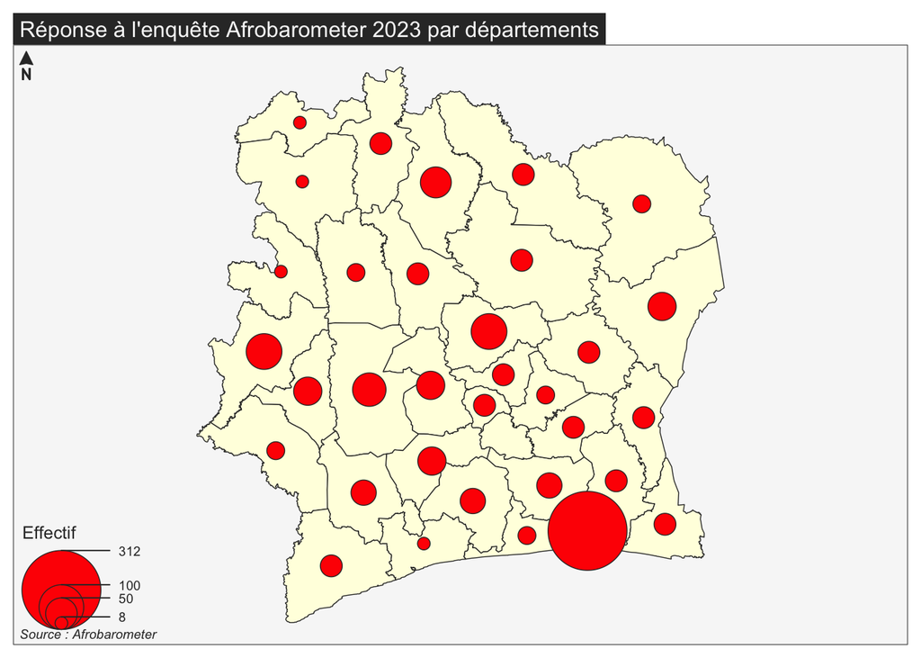

Il sera donc prudent si l’on veut cartographier les résultats de regrouper les réponses au niveau des 14 districts voire à un niveau encore plus élevé car certains districts ont encore un effectif très faible, notamment Denguélé (16 réponses) et Yamoussoukro(24 réponses)

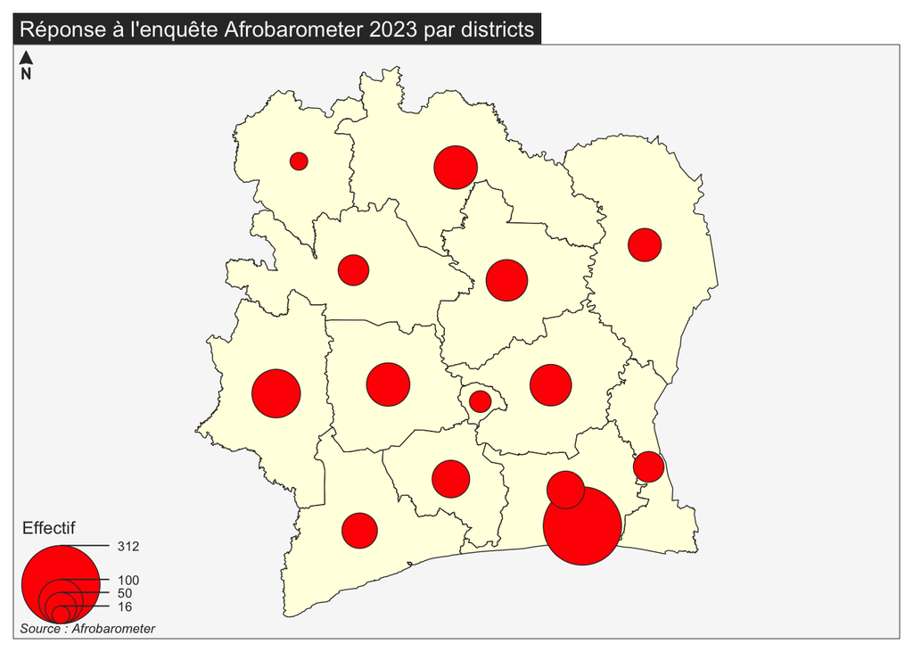

### Utilisation avec R

L’enquête Afrobarometer sera donc principalement exploitée avec R dans le cadre des cours de statistique sur les données d’enquête. Elle permettra notamment d’illustrer les méthodes de recodage de variable qualitative pour produire des tris à plat ou des tableaux de contingence sur lesquels on pourra effectuer des tests du chi-2. Les plus avancés en statistique pourront également utiliser ces données pour des cours de régression logitique, analyse des correspondances, etc.

Examinons juste à titre d’exemple le test d’une hypothèse mettant en relation le sexe (X) et le fait d’avoir reçu une vaccination contre le Covid-19 (Y).

```
X
Homme Femme
  598   602
```

```
Y
Non vacciné     Vacciné
        768         432
```

```
       Y
X       Non vacciné Vacciné  Sum
  Homme         362     236  598
  Femme         406     196  602
  Sum           768     432 1200
```

```
       Y
X       Non vacciné Vacciné Total
  Homme  60.5        39.5   100.0
  Femme  67.4        32.6   100.0
  All    64.0        36.0   100.0
```

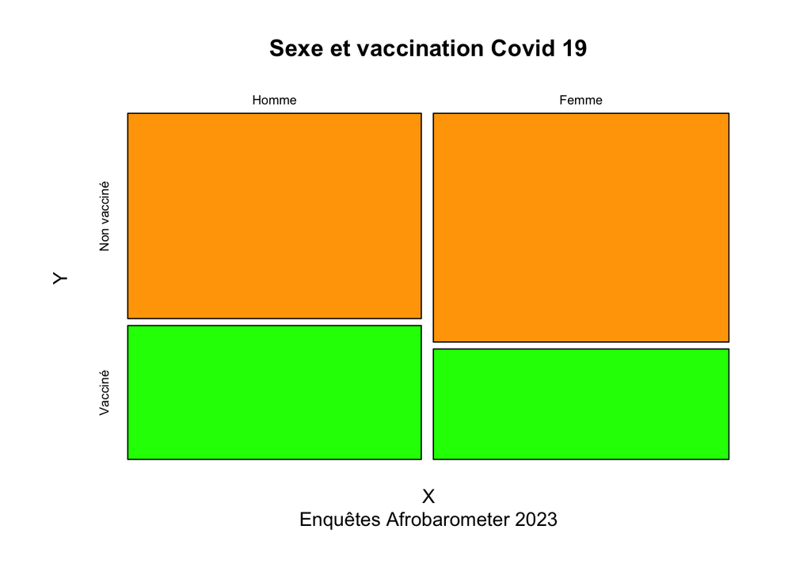

```
    Pearson's Chi-squared test with Yates' continuity correction

data:  tabcont
X-squared = 5.9151, df = 1, p-value = 0.01501
```

On constate que les hommes sont un peu plus nombreux (39.5%) que les femmes (32.6%) à déclarer avoir reçu une vacination contre le Covid-19 au moment de l’enquête Afrobarometer de 2023. Le test du chi-2 montre que la relation est légèrement significative (p < 0.05).